# Assignment 2

Tejas Athni

10/9/2020

This report summarizes my analysis of education outcomes in Santa Clara County, CA. I have chosen Santa Clara County, CA as the focal region for all studies included in this report (equity analysis, internet access analysis, and mobility analysis).

SETUP: In this first chunk of code, I load the relevant libraries of interest and set the census key.

```r
library(tidyverse)
library(plotly)
library(sf)
library(tigris)
library(leaflet)
library(censusapi)
library(tidycensus)
Sys.setenv(CENSUS_KEY="0b20d8e27e52741cf293056779d3caf7e3793f0a")
setwd("E:/SynologyDrive/Tejas_Server/! Stanford University/! Year 3 - Quarter 1/PoliSci 218X/Assignment 2")
```

EQUITY ANALYSIS PT. 1: Using the census data for code C15002 (SEX BY EDUCATIONAL ATTAINMENT) for Santa Clara County, I set out to perform an equity analysis on educational attainment by race. An important thing to note is that the data provided by the census and used in this analysis defines “population” as those equal to or above the age of 25 years.

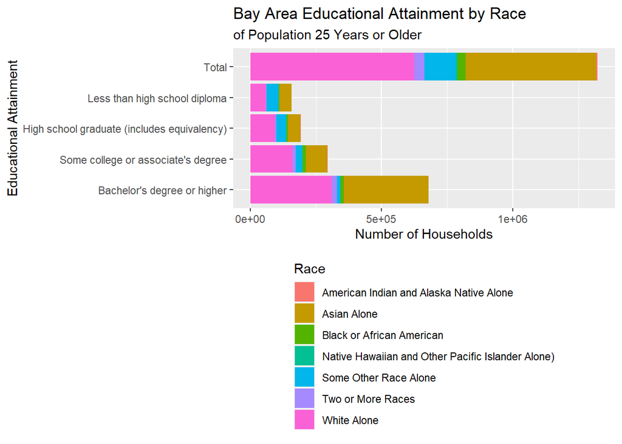

```r
acs_vars_2018_5yr <-
  listCensusMetadata(
    name = "2018/acs/acs5",
    type = "variables"
  )

census_race_labels <-
  c("White Alone",
    "Black or African American",
    "American Indian and Alaska Native Alone",
    "Asian Alone",
    "Native Hawaiian and Other Pacific Islander Alone)",
    "Some Other Race Alone",
    "Two or More Races")

bay_education_race <- 1:7 %>%
  map_dfr(function(x){
    getCensus(
      name = "acs/acs5",
      vintage = 2018,
      region = "county:085",
      regionin = "state:06",
      vars = paste0("group(C15002",LETTERS[x],")")
    ) %>%
      select(!c(GEO_ID,state,NAME) & !ends_with(c("EA","MA","M"))) %>%
      pivot_longer(
        ends_with("E"),
        names_to = "variable",
        values_to = "estimate"
      ) %>%
      left_join(
        acs_vars_2018_5yr %>%
          select(name, label),
        by = c("variable" = "name")
      ) %>%
      select(-variable) %>%
      separate(
        label,
        into = c(NA,NA,"gender","education"),
        sep = "!!"
      ) %>%
      filter(!is.na(gender)) %>% filter(!is.na(education)) %>%
      mutate(race = census_race_labels[x]) %>%
      group_by(race,education) %>%
      summarize(estimate = sum(estimate))
  })

bay_race_total <-
  bay_education_race %>%
  group_by(race) %>%
  summarize(estimate = sum(estimate)) %>%
  mutate(education = "Total")

bay_education_df <- rbind(bay_education_race, bay_race_total)


bay_education_df %>%
  ggplot() +
  geom_bar(
    aes(
      x = education %>% factor(levels = rev(c("Total","Less than high school diploma",
                                            "High school graduate (includes equivalency)",
                                            "Some college or associate's degree",
                                            "Bachelor's degree or higher"))),
      y = estimate,
      fill = race
    ),
    stat = "identity",
    position = "stack"
  ) +
  labs(
    x = "Educational Attainment",
    y = "Number of Households",
    title = "Bay Area Educational Attainment by Race",
    subtitle = "of Population 25 Years or Older",
    fill = "Race"
  ) +
  coord_flip() +
  theme(
    legend.position = "bottom",
    legend.direction = "vertical"
  )
```

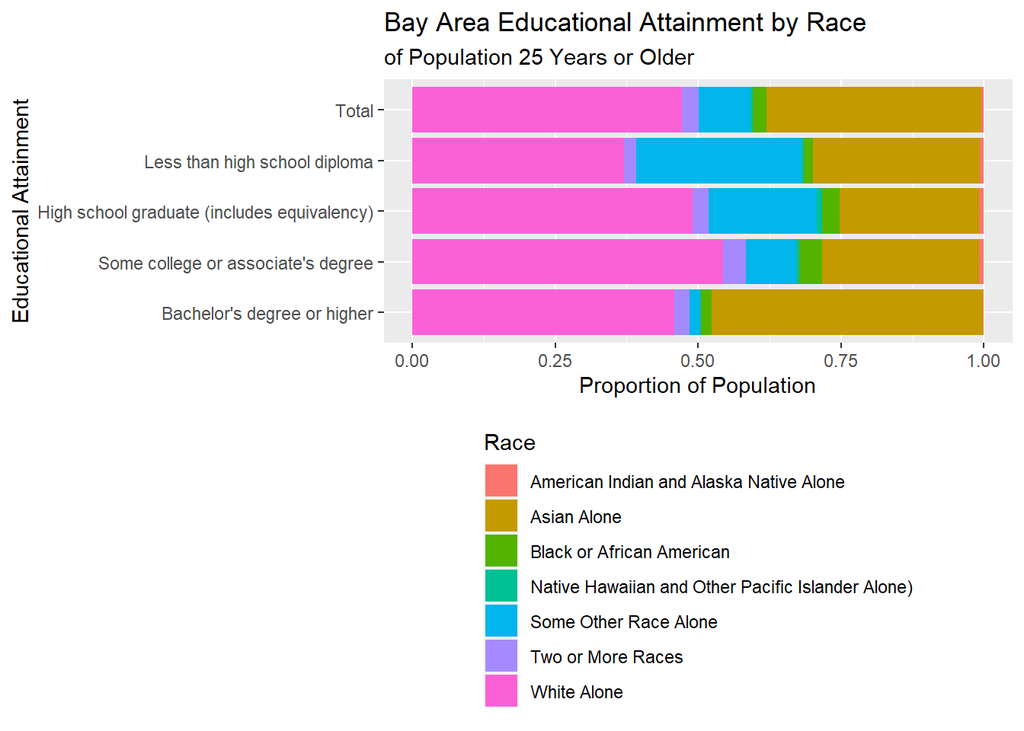

```r
bay_education_df %>%
  ggplot() +
  geom_bar(
    aes(
      x = education %>% factor(levels = rev(c("Total","Less than high school diploma",
                                            "High school graduate (includes equivalency)",
                                            "Some college or associate's degree",
                                            "Bachelor's degree or higher"))),
      y = estimate,
      fill = race
    ),
    stat = "identity",
    position = "fill"
  ) +
  labs(
    x = "Educational Attainment",
    y = "Proportion of Population",
    title = "Bay Area Educational Attainment by Race",
    subtitle = "of Population 25 Years or Older",
    fill = "Race"
  ) +
  coord_flip() +
  theme(
    legend.position = "bottom",
    legend.direction = "vertical"
  )
```

DISCUSSION: From the results of the equity analysis, it appears that there does seem to be disproportionate educational attainment by race in the Bay Area. In particular, non-Whites (i.e., operationalized as an aggregation of all races other than “White Alone”) seem to comprise a disproportionately higher portion of individuals with educational attainment of less than high school as compared to their percentage in the total population. Furthermore, on the other end of the spectrum, it seems that Asians comprise a disproportionately higher portion of those with educational attainment of Bachelor’s degree or higher as compared to their percentage in the total population.

Separately, Latinos/Hispanics are NOT represented in the U.S. census as a race, but as an ethnicity. Thus, a reasonable assumption is that those who selected “Some other race alone” as their race are likely Latinos/Hispanics. Under this assumption, Latinos make up a disproportionately higher percentage of those with less than high school education as compared to their percentage in the total population. Latinos also make up a disproportionately lower percentage of those with a bachelor’s degree or higher as compared to their percentage in the total population.

EQUITY ANALYSIS, PT. 2: Analyzing the above results, I was curious to specifically assess the exact quantitative percentage difference between the % nonwhite who comprise the population, and the % nonwhite who have less than a high school diploma (i.e., did not finish high school).

[figure not shown]

```r
perc_nonwhite_belowHS <-
  ((bay_education_df %>%
  filter(education == "Less than high school diploma") %>%
  filter(race != "White Alone") %>%
  pull(estimate) %>%
  sum()) /
  (bay_education_df %>%
    filter(education == "Less than high school diploma") %>%
    pull(estimate) %>%
    sum()) * 100) %>%
  round()

perc_nonwhite_bachelors <-
  ((bay_education_df %>%
  filter(education == "Bachelor's degree or higher") %>%
  filter(race != "White Alone") %>%
  pull(estimate) %>%
  sum()) /
  (bay_education_df %>%
    filter(education == "Bachelor's degree or higher") %>%
    pull(estimate) %>%
    sum()) * 100) %>%
  round()

perc_nonwhite_pop <- ((sum(bay_race_total$estimate[1:6])/sum(bay_race_total$estimate))*100) %>% round()

perc_nonwhite_belowHS_df <- data.frame(Group = c("% Nonwhite in Population","% Nonwhite without High School"), Percentage = c(perc_nonwhite_belowHS, perc_nonwhite_pop))


ggplot(perc_nonwhite_belowHS_df, aes(Group, Percentage)) +
  geom_col() +
  scale_y_continuous(limits = c(0,100))
```

```r
((((bay_education_df %>%
  filter(education == "Less than high school diploma") %>%
  filter(race != "White Alone") %>%
  pull(estimate) %>%
  sum()) /
  (bay_education_df %>%
    filter(education == "Less than high school diploma") %>%
    pull(estimate) %>%
    sum())) / (sum(bay_race_total$estimate[1:6])/sum(bay_race_total$estimate)) - 1) * 100) %>%
  round()
```

```
## [1] 19
```

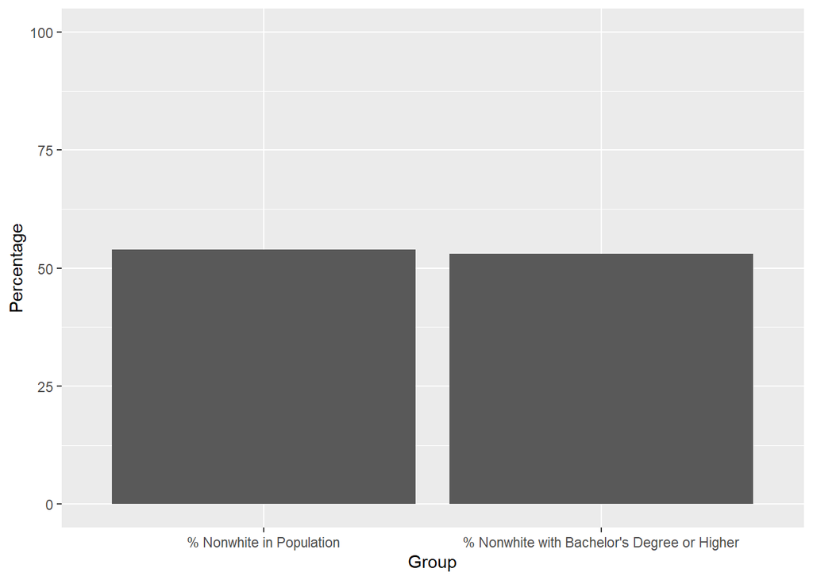

```r
perc_nonwhite_bachelors_df <- data.frame(Group = c("% Nonwhite in Population","% Nonwhite with Bachelor's Degree or Higher"), Percentage = c(perc_nonwhite_bachelors, perc_nonwhite_pop))


ggplot(perc_nonwhite_bachelors_df, aes(Group, Percentage)) +
  geom_col() +
  scale_y_continuous(limits = c(0,100))
```

One of the critical caveats in this analysis is that I am comparing all White people to the lumped aggregate of all non-white people. This particular approach allows an easy comparison between persons of color and whites, yet is fundamentally limited in that it is not an analysis about specific races (e.g., Black, Asian, etc.) in comparison to the White population.

INTERNET ACCESS FOR K-12 STUDENTS IN SANTA CLARA COUNTY: Here, I analyze the number and percentage of K-12 students who have no internet access at home using PUMS data.

```r
census_api_key("0b20d8e27e52741cf293056779d3caf7e3793f0a")

pums_vars_2018 <-
  pums_variables %>%
  filter(year == 2018, survey == "acs5")

ca_pums <- get_pums(
  variables = c(
    "PUMA",
    "NP",
    "SCHG",
    "ACCESS"
  ),
  state = "CA",
  year = 2018,
  survey = "acs1",
  recode = T
)
```

```r
ca_pumas <- pumas("CA", cb = T, progress_bar = F)
ca_counties <- counties("CA", cb = T, progress_bar = F)
bay_county_names <- c("Alameda",
                      "Contra Costa",
                      "Marin",
                      "Napa",
                      "San Francisco",
                      "San Mateo",
                      "Santa Clara",
                      "Solano",
                      "Sonoma")
bay_counties <- ca_counties %>% filter(NAME %in% bay_county_names)
santa_clara <- ca_counties %>% filter(NAME == "Santa Clara")

bay_pumas <-
  ca_pumas %>%
  st_centroid() %>%
  .[bay_counties, ] %>%
  st_set_geometry(NULL) %>%
  left_join(ca_pumas %>% select(GEOID10)) %>%
  st_as_sf()

bay_pums <-
  ca_pums %>%
  filter(PUMA %in% bay_pumas$PUMACE10)

santa_clara_pumas <-
  ca_pumas %>%
  st_centroid() %>%
  .[santa_clara, ] %>%
  st_set_geometry(NULL) %>%
  left_join(ca_pumas %>% select(GEOID10)) %>%
  st_as_sf()

santa_clara_pums <-
  ca_pums %>%
  filter(PUMA %in% santa_clara_pumas$PUMACE10)

bay_pums_K12 <- bay_pums %>%
  mutate(SCHG = str_remove(SCHG, "^0")) %>%
  filter(SCHG %in% 2:14) %>%
  mutate(estimate_noInternet = ifelse(ACCESS == 3, PWGTP, 0))

bay_pums_noInternet <- bay_pums_K12 %>%
  group_by(PUMA) %>%
  summarize(
    perc_noInternet = sum(estimate_noInternet, na.rm=T)/sum(PWGTP, na.rm=T) * 100
  ) %>%
   left_join(
    bay_pumas %>%
      select(PUMACE10),
    by = c("PUMA" = "PUMACE10")
  ) %>%
  st_as_sf()


santa_clara_pums_noInternet <- subset(bay_pums_K12, PUMA %in% santa_clara_pumas$PUMACE10) %>%
  mutate(county = "Santa Clara County") %>%
  group_by(county) %>%
  summarize(
    perc_noInternet = sum(estimate_noInternet, na.rm=T)/sum(PWGTP, na.rm=T) * 100,
    total_noInternet = sum(estimate_noInternet, na.rm=T)
  )

bay_aggregate_noInternet <- bay_pums_K12 %>%
  summarize(
    perc_noInternet = sum(estimate_noInternet, na.rm=T)/sum(PWGTP, na.rm=T) * 100,
    total_noInternet = sum(estimate_noInternet, na.rm=T)
  )

paste0("Santa Clara County, K-12 students without internet: ",santa_clara_pums_noInternet$total_noInternet)
```

```
## [1] "Santa Clara County, K-12 students without internet: 8388"
```

```r
paste0("Santa Clara County, K-12 students without internet: ",round(santa_clara_pums_noInternet$perc_noInternet,digits=2),"%")
```

```
## [1] "Santa Clara County, K-12 students without internet: 2.69%"
```

```r
paste0("Bay Area aggregate, K-12 students without internet: ",bay_aggregate_noInternet$total_noInternet)
```

```
## [1] "Bay Area aggregate, K-12 students without internet: 28761"
```

```r
paste0("Bay Area aggregate, K-12 students without internet: ",round(bay_aggregate_noInternet$perc_noInternet,digits=2),"%")
```

```
## [1] "Bay Area aggregate, K-12 students without internet: 2.49%"
```

One assumption I have used in this analysis is that the one-time “snapshot” of the census accurately represents the amount and percent of K-12 students who did not have access to internet. In reality, these numbers likely fluctuate over the course of a year, often drastically due to IT infrastructure problems at the household level or larger-scale environmental effects such as multiple days of thunderstorms knocking out internet. For the purposes of my analysis, I assume that such “temporary” effects are non-existent and that all respondents who chose “no internet” actually do not have internet access for prolonged, year-round periods of time. Another assumption is that parents remember to accurately fill out young children’s internet access census data, even when these metrics for such young kids might be easily overshadowed.

Holistically, although this census data analysis provides overarching long-term insights on lack of internet access, it might not be the best for understanding challenges of remote learning in 2020. More temporally-granular data, available at the monthly scale, might help to shine light on the real dynamics of lacking internet access during a pandemic. This sort of data might be obtained from local school districts or school boards, but might be less feasible to obtain due to the timescale of their response and potential privacy concerns regarding potentially identifiable data.

INTERNET ACCESS FOR K-12 STUDENTS IN BAY AREA: Here, I plot a map of K-12 students lacking internet access.

```r
pums_pal <- colorNumeric(
  palette = "Reds",
  domain = bay_pums_noInternet$perc_noInternet
)

leaflet() %>%
  addTiles() %>%
  addPolygons(
    data = bay_pums_noInternet,
    fillColor = ~pums_pal(perc_noInternet),
    color = "grey",
    opacity = 0.6,
    fillOpacity = 0.7,
    weight = 1,
    label = ~paste0(
      round(perc_noInternet),
      "% K-12 students lacking internet access"
    ),
    highlightOptions = highlightOptions(
      weight = 2,
      opacity = 1
    )
  ) %>%
  addLegend(
    data = bay_pums_noInternet,
    pal = pums_pal,
    values = ~perc_noInternet,
    title = "% K-12 students<br>in the Bay Area<br>lacking access<br>
    to the internet"
  )
```

[interactive chart not shown]

MIGRATION ANALYSIS: Here, I perform a migration analysis using data on educational attainment.

```r
acs_vars_2019_1yr <-
  listCensusMetadata(
    name = "2019/acs/acs1",
    type = "variables"
  )

scc_mobility_current_19 <-
  getCensus(
    name = "acs/acs1",
    vintage = 2019,
    region = "county:085",
    regionin = "state:06",
    vars = c("group(B07009)")
  ) %>%
  select(!c(GEO_ID,state,NAME) & !ends_with(c("EA","MA","M"))) %>%
  pivot_longer(
    ends_with("E"),
    names_to = "variable",
    values_to = "estimate"
  ) %>%
  left_join(
    acs_vars_2019_1yr %>%
      select(name, label),
    by = c("variable" = "name")
  ) %>%
  select(-variable) %>%
  separate(
    label,
    into = c(NA,NA,"mobility","education"),
    sep = "!!"
  ) %>%
  mutate(
    mobility = ifelse(
      mobility %in% c("Same house 1 year ago:", "Moved within same county:"),
      "Here since last year",
      "Inflow"
    )
  ) %>%
  filter(!is.na(education)) %>%
  group_by(mobility, education) %>%
  summarize(estimate = sum(estimate))


scc_mobility_lastyear_19 <-
  getCensus(
    name = "acs/acs1",
    vintage = 2019,
    region = "county:085",
    regionin = "state:06",
    vars = c("group(B07409)")
  ) %>%
  select(!c(GEO_ID,state,NAME) & !ends_with(c("EA","MA","M"))) %>%
  pivot_longer(
    ends_with("E"),
    names_to = "variable",
    values_to = "estimate"
  ) %>%
  left_join(
    acs_vars_2019_1yr %>%
      select(name, label),
    by = c("variable" = "name")
  ) %>%
  select(-variable) %>%
  separate(
    label,
    into = c(NA,NA,"mobility","education"),
    sep = "!!"
  ) %>%
  mutate(
    mobility = ifelse(
      mobility %in% c("Same house:", "Moved within same county:"),
      "Here since last year",
      "Outflow"
    )
  ) %>%
  filter(!is.na(education)) %>%
  group_by(mobility, education) %>%
  summarize(estimate = sum(estimate))


scc_mobility_current_18 <-
  getCensus(
    name = "acs/acs1",
    vintage = 2018,
    region = "county:085",
    regionin = "state:06",
    vars = c("group(B07009)")
  ) %>%
  select(!c(GEO_ID,state,NAME) & !ends_with(c("EA","MA","M"))) %>%
  pivot_longer(
    ends_with("E"),
    names_to = "variable",
    values_to = "estimate"
  ) %>%
  left_join(
    acs_vars_2019_1yr %>%
      select(name, label),
    by = c("variable" = "name")
  ) %>%
  select(-variable) %>%
  separate(
    label,
    into = c(NA,NA,"mobility","education"),
    sep = "!!"
  ) %>%
  mutate(
    mobility = "Here last year"
  ) %>%
  filter(!is.na(education)) %>%
  group_by(mobility, education) %>%
  summarize(estimate = sum(estimate))


scc_flows_19 <-
  rbind(
    scc_mobility_current_18,
    scc_mobility_lastyear_19 %>%
      filter(mobility == "Outflow"),
    scc_mobility_current_19 %>%
      filter(mobility == "Inflow"),
    scc_mobility_current_19 %>%
      group_by(education) %>%
      summarize(estimate = sum(estimate)) %>%
      mutate(mobility = "Here this year")
  ) %>%
  pivot_wider(
    names_from = mobility,
    values_from = estimate
  ) %>%
  mutate(
    `External net` = Inflow - Outflow,
    `Internal net` = `Here this year` - `Here last year` - `External net`,
  ) %>%
  select(
    `Educational Attainment` = education,
    `Internal net`,
    `External net`,
    `Here last year`,
    `Here this year`,
    Outflow,
    Inflow
  )


scc_flows_19$orderNum <- c(4,5,2,1,3)
scc_flows_19 <- scc_flows_19[order(scc_flows_19$orderNum),] %>%
  select(-orderNum)

scc_flows_19
```

```
## # A tibble: 5 x 7
##   `Educational At~ `Internal net` `External net` `Here last year`
##   <chr>                     <dbl>          <dbl>            <dbl>
## 1 Less than high ~           3780           -180           145290
## 2 High school gra~             56           1123           184686
## 3 Some college or~            119          -3394           293946
## 4 Bachelor's degr~          -4379           -236           383232
## 5 Graduate or pro~          -6143          10166           342615
## # ... with 3 more variables: `Here this year` <dbl>, Outflow <dbl>,
## #   Inflow <dbl>
```

DISCUSSION: Net external influx is highest in Santa Clara County for those with graduate or professional degree. This could be due to increasing teaching and professorship hires in academia (e.g., Stanford University, San Jose State University, Santa Clara University, Mission College, De Anza College) and high-powered industry and tech jobs in Silicon Valley, which is located in the county (e.g., Intel, Sun Microsystems, Nvidia). The second highest net external influx is those with a high school diploma, perhaps due to manufacturing, services, or retail job opportunities. On the whole, it seems that those with the highest levels of education are coming into the county at the highest amount, and those with the lowest educational attainment and “medium” education (e.g., some college) are leaving the county.

Interestingly, internal net migration (e.g., due to births, deaths, and non-external movement) decreases as the educational attainment increases in a seemingly inverse relationship. This could be attributed to people with lower educational attainment having more children earlier, and women of higher educational attainment have a later family start time due to delayed career independence. Further, this could also be due to a purely statistical effect whereby those with a bachelor’s degree or graduate degree– groups whom make up most of the SCC population– are simply dying at higher rates because they comprise more of the elderly population.

Taken holistically, there does NOT seem to be an overarching trend that those with lower education are attaining higher education within the county itself and gaining upward educational mobility, or that educated folk are massively displacing the lower-educated population. Rather, there is a mix of education levels comprising of the inflow group (namely, graduate-educated and high-school educated folks), and a mix of education levels comprising the outflow group (namely, folks with some college or an associate’s/bachelor’s degree). However, more granular data, obtained from a source such as the regional labor bureau or education bureau, might help to shine further insights on this issue; although, the feasibility of obtaining this data might be a challenge due to these agencies’ current COVID priorities and possible stakeholder privacy concerns in sharing such data.